# 2020 HINTS Project

Karinna Alatorre, Katrina Huynh, Jaime Rosas, and Linda Zavala

2026-03-08

# 2020 Health Information National Trends Survey (HINTS) Analysis

Project Objectives: This project analyzes data from the 2020 Health Information National Trends Survey (HINTS). The goal is to examine health behaviors and demographic characteristics.

## HINTS Data Import

```r
hints.data <- read.csv("C:/Users/zlind/Downloads/HINTSData_2020_clean.csv")
```

The following data focuses on the variables:

Age, AvgDrinksPerWeek, WeeklyMinutesModerateExcersice, BMI, QualityCare, BirthGender, smokeStat, and RaceEthn5.

## Statistical Descriptive Analysis

### Age

The average age HINTS participant was approximately 56, the youngest participant was 18 and the oldest participant was 100 years of age. Furthermore, the median age was 58.

```r
summary(hints.data$Age, na.rm=TRUE)
```

```
##    Min. 1st Qu.  Median    Mean 3rd Qu.    Max.
##   18.00   43.00   58.00   55.59   68.00  100.00
```

#### Statistical summary of age utilizing the ‘skimr’ package

```r
skim(hints.data$Age) # provides statistical summary for 'Age' using 'skim' package
```

Data summary

| Name | hints.data$Age |
| --- | --- |
| Number of rows | 2402 |
| Number of columns | 1 |
| _______________________ |  |
| Column type frequency: |  |
| numeric | 1 |
| ________________________ |  |
| Group variables | None |

**Variable type: numeric**

| skim_variable | n_missing | complete_rate | mean | sd | p0 | p25 | p50 | p75 | p100 | hist |
| --- | --- | --- | --- | --- | --- | --- | --- | --- | --- | --- |
| data | 0 | 1 | 55.59 | 16.58 | 18 | 43 | 58 | 68 | 100 | ▃▅▇▅▁ |

### Average Drinks Per Week

The average drinks per week HINTS participant drank was about 3, the lowest was 0, and the highest was 70.

```r
summary(hints.data$AvgDrinksPerWeek, na.rm = TRUE) # Descriptive summary 'AvgDrinksPerWeek' variable
```

```
##    Min. 1st Qu.  Median    Mean 3rd Qu.    Max.
##   0.000   0.000   0.000   3.358   4.000  70.000
```

#### Statistical summary of average drinks per week using the ‘skimr’ pacakge

```r
skim(hints.data$AvgDrinksPerWeek) # Statistical summary for 'AvgDrinksPerWeek' using 'skimr'
```

Data summary

| Name | hints.data$AvgDrinksPerWe… |
| --- | --- |
| Number of rows | 2402 |
| Number of columns | 1 |
| _______________________ |  |
| Column type frequency: |  |
| numeric | 1 |
| ________________________ |  |
| Group variables | None |

**Variable type: numeric**

| skim_variable | n_missing | complete_rate | mean | sd | p0 | p25 | p50 | p75 | p100 | hist |
| --- | --- | --- | --- | --- | --- | --- | --- | --- | --- | --- |
| data | 0 | 1 | 3.36 | 6.59 | 0 | 0 | 0 | 4 | 70 | ▇▁▁▁▁ |

### Weekly Minutes Moderate Exercise

```r
summary(hints.data$WeeklyMinutesModerateExercise) # Five-number summary and mean
```

```
##    Min. 1st Qu.  Median    Mean 3rd Qu.    Max.
##     0.0     0.0    90.0   161.8   210.0  4620.0
```

```r
sd(hints.data$WeeklyMinutesModerateExercise, na.rm = TRUE) # Standard deviation
```

```
## [1] 271.1893
```

```r
var(hints.data$WeeklyMinutesModerateExercise, na.rm = TRUE) # Variance
```

```
## [1] 73543.61
```

#### Statistical summary of WeeklyMinutesModerateExcerise using the ‘skimr’ pacakge

```r
skim(hints.data$WeeklyMinutesModerateExercise)
```

Data summary

| Name | hints.data$WeeklyMinutesM… |
| --- | --- |
| Number of rows | 2402 |
| Number of columns | 1 |
| _______________________ |  |
| Column type frequency: |  |
| numeric | 1 |
| ________________________ |  |
| Group variables | None |

**Variable type: numeric**

| skim_variable | n_missing | complete_rate | mean | sd | p0 | p25 | p50 | p75 | p100 | hist |
| --- | --- | --- | --- | --- | --- | --- | --- | --- | --- | --- |
| data | 0 | 1 | 161.78 | 271.19 | 0 | 0 | 90 | 210 | 4620 | ▇▁▁▁▁ |

### BMI

The lowest BMI value among the HINTS participants was 10.90 and the highest was approximately 73.80. The average BMI among participants was 28.61.

```r
summary(hints.data$BMI, na.rm = TRUE)
```

```
##    Min. 1st Qu.  Median    Mean 3rd Qu.    Max.
##   10.90   24.00   27.50   28.61   31.90   73.80
```

```r
var(hints.data$BMI, na.rm = TRUE)
```

```
## [1] 42.75028
```

#### Statistical summary of BMI using the ‘skimr’ pacakge

```r
skim(hints.data$BMI)
```

Data summary

| Name | hints.data$BMI |
| --- | --- |
| Number of rows | 2402 |
| Number of columns | 1 |
| _______________________ |  |
| Column type frequency: |  |
| numeric | 1 |
| ________________________ |  |
| Group variables | None |

**Variable type: numeric**

| skim_variable | n_missing | complete_rate | mean | sd | p0 | p25 | p50 | p75 | p100 | hist |
| --- | --- | --- | --- | --- | --- | --- | --- | --- | --- | --- |
| data | 0 | 1 | 28.61 | 6.54 | 10.9 | 24 | 27.5 | 31.9 | 73.8 | ▂▇▁▁▁ |

### Statistical summaries based on three different smoking status

Smoking status corresponds to ordered response categories. See key below.

Key

1 Current

2 Former

3 Never

#### Age

The average age for current smokers is 54, for former smokers is 61, and for individuals who never smoked is 53.

```r
hints.data %>%
  group_by (smokeStat) %>%
  summarise (
    mean_age = mean(Age, na.rm=TRUE), # displays mean of 'Age'
    median_age = median(Age, na.rm=TRUE), # displays median of 'Age'
    sd_age = sd(Age, na.rm=TRUE), # displays standard deviation of 'Age'
    q25_age = quantile(Age, 0.25, na.rm=TRUE), # displays 0.25 qt of 'Age'
    q75_age = quantile(Age, 0.75, na.rm=TRUE), # displays 0.75 qt of 'Age'
    var_age = var(Age, na.rm = TRUE)
  )
```

```
## # A tibble: 3 × 7
##   smokeStat mean_age median_age sd_age q25_age q75_age var_age
##       <int>    <dbl>      <dbl>  <dbl>   <dbl>   <dbl>   <dbl>
## 1         1     54.5         57   14.5      44      65    212.
## 2         2     61.4         64   14.8      52      72    219.
## 3         3     53.4         55   17.0      39      66    290.
```

#### Average Drinks per Week

```r
hints.data %>%
  group_by(smokeStat) %>%
  summarise(
    mean_avgdrinksperweek = mean(AvgDrinksPerWeek, na.rm = TRUE), # Mean
    median_avgdrinksperweek = median(AvgDrinksPerWeek, na.rm = TRUE), # Median
    sd_avgdrinksperweek = sd(AvgDrinksPerWeek, na.rm = TRUE), # Standard deviation
    q25_avgdrinksperweek = quantile(AvgDrinksPerWeek, 0.25, na.rm = TRUE), # 25th percentile
    q75_avgdrinksperweek = quantile(AvgDrinksPerWeek, 0.75, na.rm = TRUE), # 75th percentile
    var_avgdrinksperweek = var(AvgDrinksPerWeek, na.rm = TRUE)) # Variance
```

```
## # A tibble: 3 × 7
##   smokeStat mean_avgdrinksperweek median_avgdrinksperweek sd_avgdrinksperweek
##       <int>                 <dbl>                   <dbl>               <dbl>
## 1         1                  4.87                       0                9.31
## 2         2                  4.41                       1                7.78
## 3         3                  2.68                       0                5.31
## # ℹ 3 more variables: q25_avgdrinksperweek <dbl>, q75_avgdrinksperweek <dbl>,
## #   var_avgdrinksperweek <dbl>
```

#### Weekly Minutes Moderate Exercise

On average current smokers perform 154 minutes of exercise weekly. Former smokers perform an average 174 minutes weekly, and participants who never smoked perform an average of 158 minutes of exercise weekly.

```r
hints.data %>%
  group_by(smokeStat) %>%
  summarise(
    mean_weeklyexercise = mean(WeeklyMinutesModerateExercise, na.rm = TRUE), # Mean
    med_weeklyexercise = median(WeeklyMinutesModerateExercise),
    sd_weeklyexercise = sd(WeeklyMinutesModerateExercise, na.rm = TRUE), # Standard deviation
    var_weeklyexercise = var(WeeklyMinutesModerateExercise, na.rm = TRUE), # Variance
q_25_weeklyminmoderateexercise = quantile(WeeklyMinutesModerateExercise, 0.25),
q_75 = quantile(WeeklyMinutesModerateExercise, 0.75))
```

```
## # A tibble: 3 × 7
##   smokeStat mean_weeklyexercise med_weeklyexercise sd_weeklyexercise
##       <int>               <dbl>              <dbl>             <dbl>
## 1         1                154.                 60              310.
## 2         2                174.                 90              305.
## 3         3                158.                 90              249.
## # ℹ 3 more variables: var_weeklyexercise <dbl>,
## #   q_25_weeklyminmoderateexercise <dbl>, q_75 <dbl>
```

#### BMI

Current, former, and participants who never smoked have an average BMI of 28.

```r
hints.data %>%
  group_by(smokeStat) %>% #group the dataset by smoking status
  summarise(
    bmi.mean = mean(BMI), #mean BMI for each smoking group
    bmi.med = median(BMI), #median
    bmi.sd = sd(BMI), #standard deviation of BMI
    bmi.var = var(BMI), #variance of the BMI
     bmi.q25 = quantile(BMI, 0.25), #0.25 qt of BMI
    bmi.q75 = quantile(BMI, 0.75) #0.75 of BMI
  )
```

```
## # A tibble: 3 × 7
##   smokeStat bmi.mean bmi.med bmi.sd bmi.var bmi.q25 bmi.q75
##       <int>    <dbl>   <dbl>  <dbl>   <dbl>   <dbl>   <dbl>
## 1         1     28.7    27.6   6.60    43.6    23.9    33.3
## 2         2     28.8    27.8   6.34    40.2    24.2    32.1
## 3         3     28.5    27.5   6.61    43.7    23.8    31.6
```

### Function for Descriptive Statistics

A single function labeled “my_summary_func” to display the results of the stat summaries in B.1

```r
#creating a function to summarize the statistical summaries of the continuous variables of interest

my_summary_func <- function(x) { #defines a function
  list(
    Mean = mean(x),#mean
    SD = sd (x), #standard deviation
    Variance = var(x), #vairance
    Five.Num.Summary = summary(x) #five summary
  )
}

#applying my_summary_function to all continuous variables
my_summary_func(hints.data$Age) #Age
```

```
## $Mean
## [1] 55.59117
##
## $SD
## [1] 16.57902
##
## $Variance
## [1] 274.864
##
## $Five.Num.Summary
##    Min. 1st Qu.  Median    Mean 3rd Qu.    Max.
##   18.00   43.00   58.00   55.59   68.00  100.00
```

```r
my_summary_func(hints.data$BMI) #BMI
```

```
## $Mean
## [1] 28.60704
##
## $SD
## [1] 6.538369
##
## $Variance
## [1] 42.75028
##
## $Five.Num.Summary
##    Min. 1st Qu.  Median    Mean 3rd Qu.    Max.
##   10.90   24.00   27.50   28.61   31.90   73.80
```

```r
my_summary_func(hints.data$AvgDrinksPerWeek) #Avg Drinks Per Week
```

```
## $Mean
## [1] 3.358035
##
## $SD
## [1] 6.588142
##
## $Variance
## [1] 43.40362
##
## $Five.Num.Summary
##    Min. 1st Qu.  Median    Mean 3rd Qu.    Max.
##   0.000   0.000   0.000   3.358   4.000  70.000
```

```r
my_summary_func(hints.data$WeeklyMinutesModerateExercise) #Weekly Minutes Moderate Exercise
```

```
## $Mean
## [1] 161.7818
##
## $SD
## [1] 271.1893
##
## $Variance
## [1] 73543.61
##
## $Five.Num.Summary
##    Min. 1st Qu.  Median    Mean 3rd Qu.    Max.
##     0.0     0.0    90.0   161.8   210.0  4620.0
```

## Univariate Visualizations

### Quality of Care

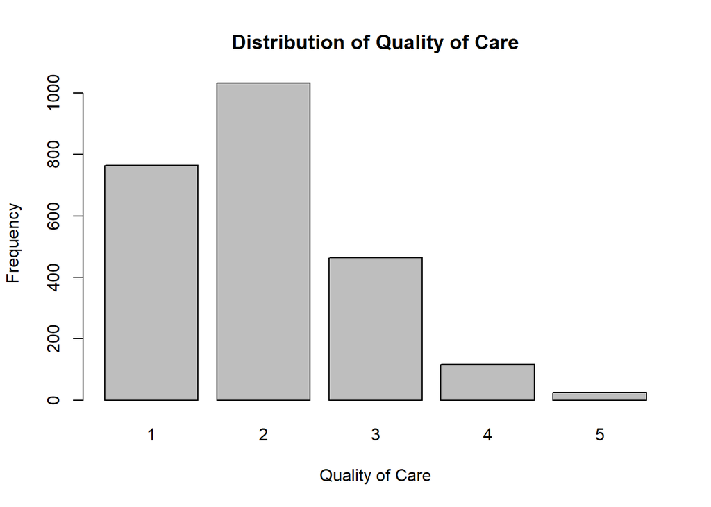

```r
#create bar graph for quality of care distribtion
barplot(table(hints.data$QualityCare), #create table
        main = "Distribution of Quality of Care", #names graph
        xlab = "Quality of Care", #labels x-axis
        ylab = "Frequency") # labels y-axis
```

Key:

1 Excellent

2 Very Good

3 Good

4 Fair

5 Poor

### Race and Ethnicity

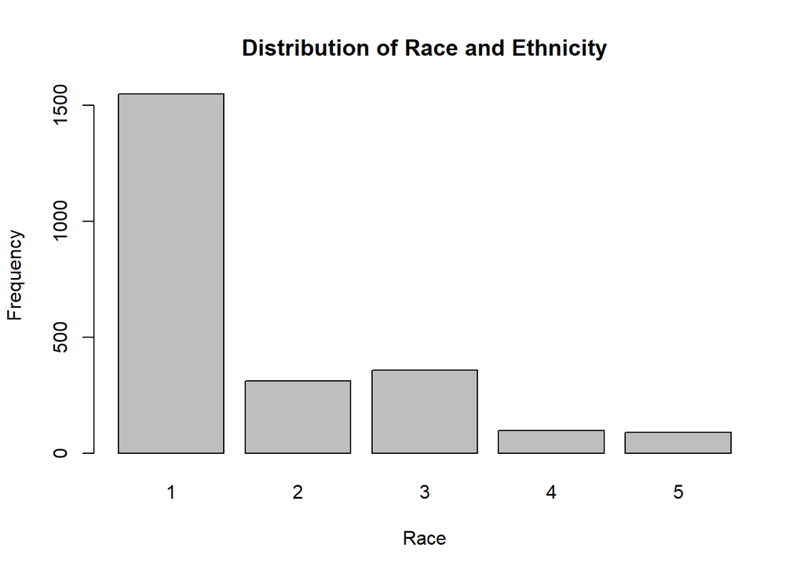

```r
#create bar graph for race and ethnicty
barplot(table (hints.data$RaceEthn5),
        main = "Distribution of Race and Ethnicity", #names graph
        xlab = "Race", #labels x-axis
        ylab = "Frequency") #labels y-axis
```

The bar chart represents the distribution of the Race and Ethnicity of the participants. Each number represents a different option. The majority of the participants were non-Hispanic white.

Key:

1 Non-Hispanic White

2 Non-Hispanic Black or African American

3 Hispanic

4 Non-Hispanic Asian

5 Non-Hispanic Other

### Age

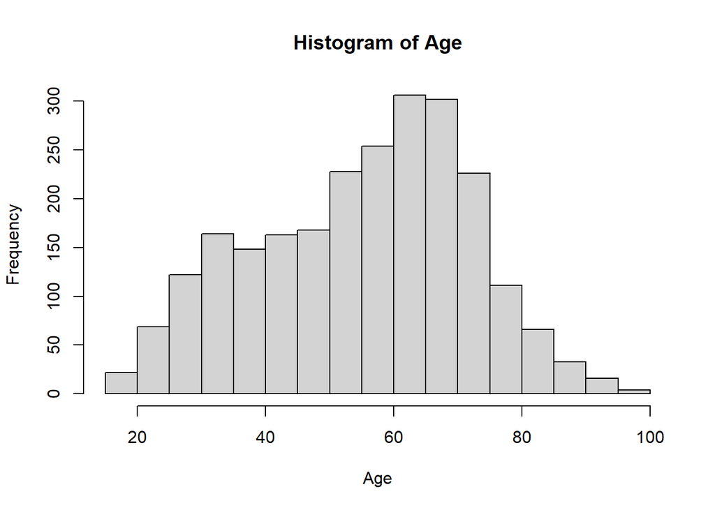

```r
hist(hints.data$Age,
     main = "Histogram of Age",
     xlab = "Age")
```

The histogram is displaying the age distribution of HINTS participants. The age distribution is left-skewed indicating that most survey participants were older.

### BMI

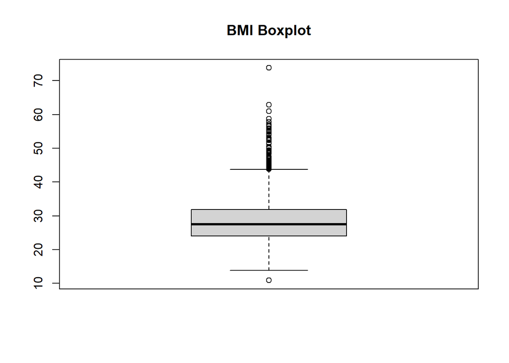

```r
boxplot (hints.data$BMI,
         main = "BMI Boxplot")
```

The boxplot is providing the five-number summary of Body Mass Index (BMI) of survey participants. The average BMI of HINTS participants was 28.61. The maximum was 73.80 and the minimum was 10.90.

### ggPlot2 Repeat Visualization

#### Distribution of Quality of Care

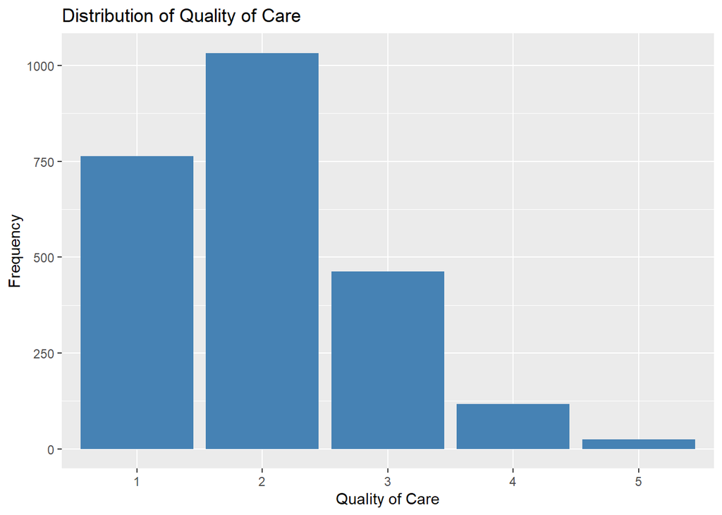

```r
ggplot(hints.data, aes(x = as.factor(QualityCare))) +
  geom_bar(fill = "steelblue") +
  labs(title = "Distribution of Quality of Care",
       x = "Quality of Care",
       y = "Frequency")
```

#### Distribution of Race and Ethnicity

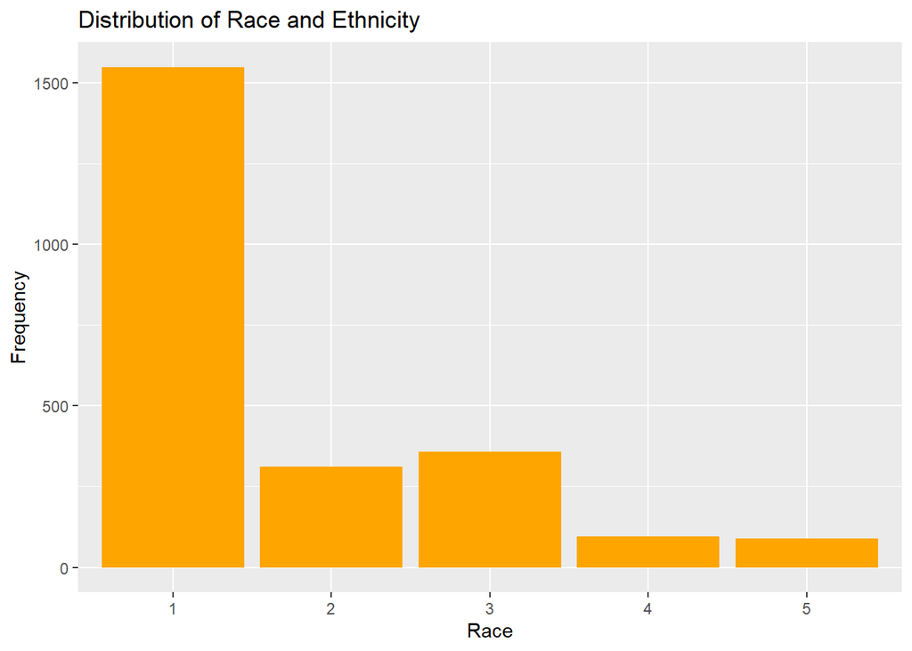

```r
ggplot(hints.data, aes(x = as.factor(RaceEthn5))) +
  geom_bar(fill = "orange") +
  labs(title = "Distribution of Race and Ethnicity",
       x = "Race",
       y = "Frequency")
```

#### Histogram of Age

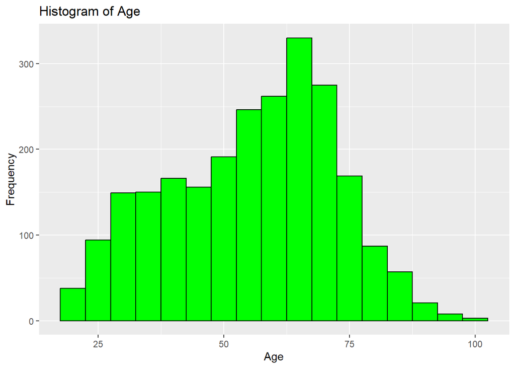

```r
ggplot(hints.data, aes(x = Age)) +
  geom_histogram(binwidth = 5, fill = "green", color = "black") +
  labs(title = "Histogram of Age",
       x = "Age",
       y = "Frequency")
```

#### Boxplot of BMI

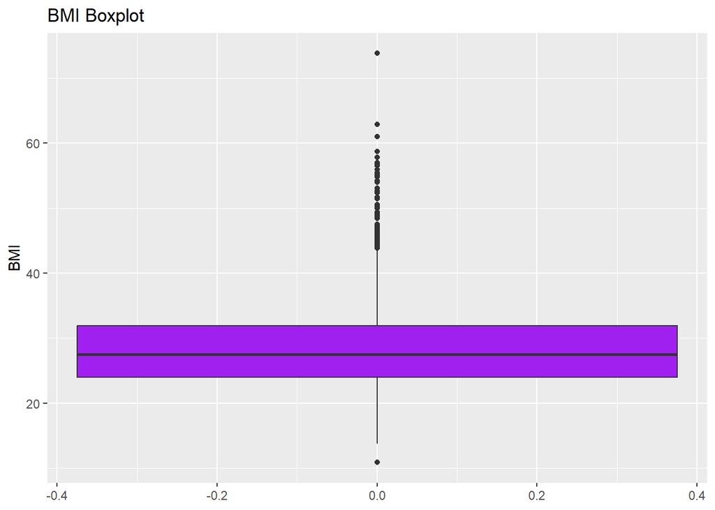

```r
ggplot(hints.data, aes(y = BMI)) +
  geom_boxplot(fill = "purple") +
  labs(title = "BMI Boxplot",
       y = "BMI")
```

### Function to Perform Analysis

A single R function to perform analysis of graphs (QualityCare, RaceEthn5, Age, BMI)

```r
# Box plot for categorical variables
my_visual_func_I <- function(data, variable) {
    ggplot(data, aes(x = factor(.data[[variable]]))) +
        geom_bar(fill = "skyblue") +
        labs(title = paste("Distribution of", variable), x = variable, y = "Count") +
        theme_minimal()
}
```

```r
# Histogram for continuous variables
my_visual_func_II <- function(data, variable) {
    ggplot(data, aes(x = .data[[variable]])) +
        geom_histogram(fill = "orange", color = "black", bins = 30) +
        labs(title = paste("Distribution of", variable), x = variable, y = "Frequency") +
        theme_minimal()
}
```

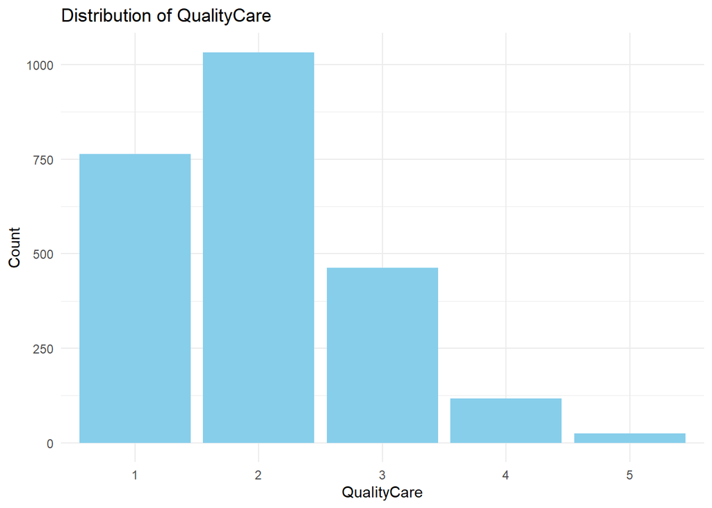

```r
# Examples
my_visual_func_I(hints.data, "QualityCare")
```

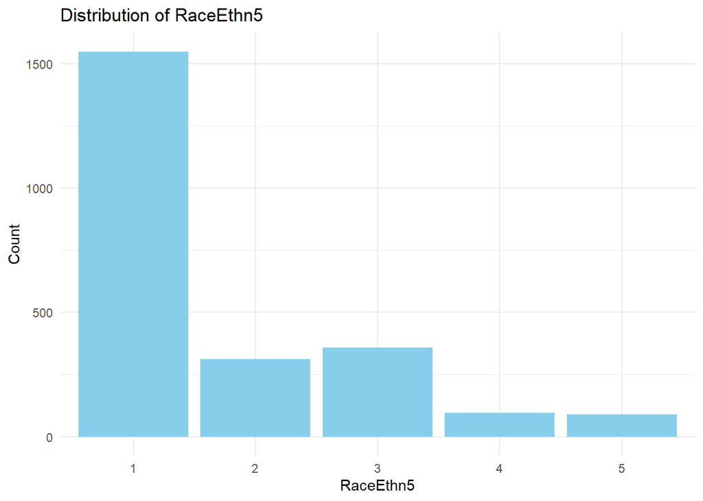

```r
my_visual_func_I(hints.data, "RaceEthn5")
```

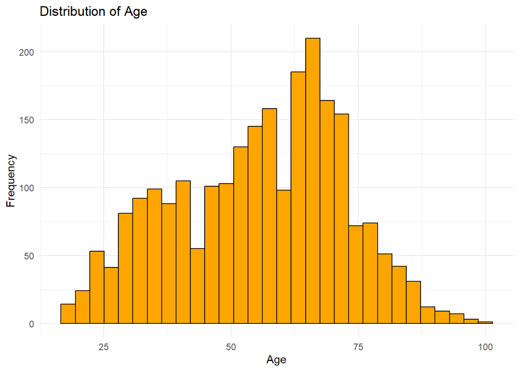

```r
my_visual_func_II(hints.data, "Age")
```

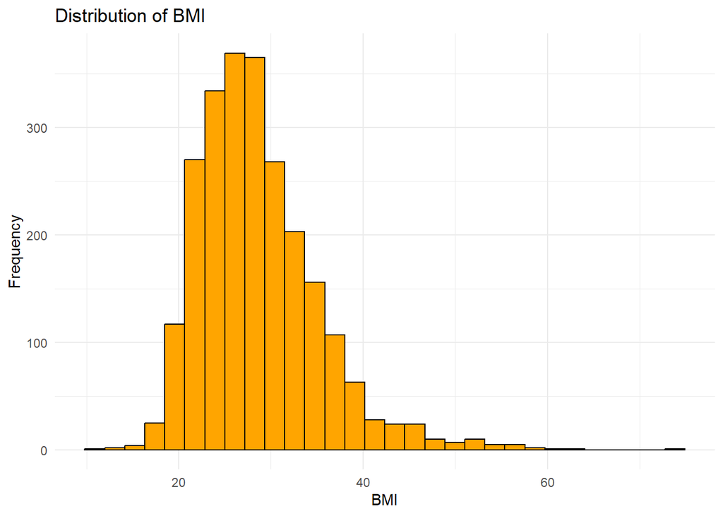

```r
my_visual_func_II(hints.data, "BMI")
```